# Deep Dive #10 - Quantum Mechanics

Its a good day to be a physics major!

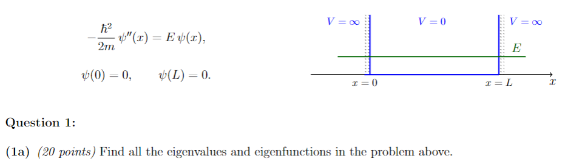

$$ \Psi''(x) + \frac{2mE}{\hbar^2}\Psi(x) = 0 \\ \lambda = \frac{2mE}{\hbar^2} $$ Can energy be negative? In this situation that would yield an exponential $\Psi$ function which cannot be zero at two points. For $E=0$ this is trivial, so we'll consider $E>0$

The characteristic polynomial is

$$ r^2 + \frac{2mE}{\hbar^2} = 0 \\ r = \pm i\frac{\sqrt{2mE}}{\hbar} $$

This yields

$$ \Psi(x) = c_+ \cos(\frac{\sqrt{2mE}}{\hbar} x) + c_- \sin(\frac{\sqrt{2mE}}{\hbar} x)\\ \Psi(0) = 0 \implies 0 = c_{+} \cos(0) \implies c_+ = 0\\ \Psi(L) = 0 \implies 0 = c_- \sin(\frac{\sqrt{2mE}}{\hbar} L) $$

With $c\neq0$, we have $\sin(n\pi) = 0 $ this gives us $$ \frac{\sqrt{2mE}}{\hbar} L = n \pi \\ \frac{\sqrt{2mE}}{\hbar} = \frac{n \pi}{L}\\ \frac{2mE}{\hbar^2} = \left( \frac{n \pi}{L} \right)^2 $$

Thus all eigenvalues are $\left( \frac{n \pi}{L} \right)^2$, and the allowed energies are

$$ E = \frac{n^2 \pi^2\hbar^2}{2mL^2} $$

and the eigenfunctions are

$$ y_n(x) = \sin(\sqrt {\lambda_n} x) = \sin(\frac{n \pi}{L}x) $$

for $c_- = 1$ (eigenfunctions can be scaled)

(1b)

$$ L = a = 3 \\ \alpha = 1, 2, 3, \dots, n \implies \lambda_n = \left(\frac{\pi}{3}\right)^2, \left(\frac{2\pi}{3}\right)^2, \left(\frac{3\pi}{3}\right)^2,\dots \left(\frac{n\pi}{L}\right)^2 $$

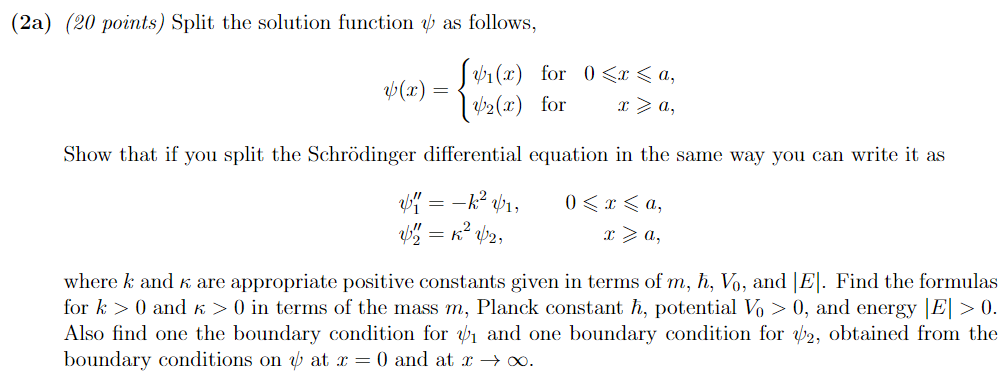

For $x<a, E-V > 0$ and we are in the well. For $x>a, E-V < 0$ we are outside the well, classically impossible.

Schrodigers equation can be split in the same way as $V(x)$

$$ \psi''(x) = \begin{cases} \frac{2m}{\hbar^2} \left(-V_0-E\right) \psi(x) & \text{for} & 0 \leq x\leq a\\ -\frac{2m}{\hbar^2}E \psi(x) & \text{for} & x\geq a \end{cases} $$ Remember that E<0 and can be represented correctly as E = -|E| $$ \psi''(x) = \begin{cases} -\frac{2m}{\hbar^2} \left(V_0-|E|\right) \psi(x) & \text{for} & 0 \leq x\leq a\\ \frac{2m}{\hbar^2}|E| \psi(x) & \text{for} & x\geq a \end{cases} $$

This gets us our k-values

$$ -k^2 = -\frac{2m}{\hbar^2} \left(V_0-|E|\right) \\ \kappa^2 = \frac{2m}{\hbar^2}|E| $$

Also $\psi_1(0)=\psi_2(\infty)=0$

2b

To be precise, there is one condition $E=-|E|$

The characteristic polynomial for $\psi_1$ yields $$ r_1^2=-k^2\\ r_1 = \pm ik \\ \psi_1(x) = c_+ \cos(kx) + c_- \sin(kx) \\ $$

And for $\psi_2$ yield

$$ r_2^2=\kappa^2\\ r_2 = \pm \kappa ^2 \\ \psi_2(x) = c_0 e^{\kappa x} + c_1 e^{-\kappa x} $$

From applying boundary condtions we see $$ \psi_1(0)=0 \implies c_+ = 0\\ \psi_2(\infty)=0 \implies c_0 = 0 $$

There's another condition at $x=a$, but we get to that later

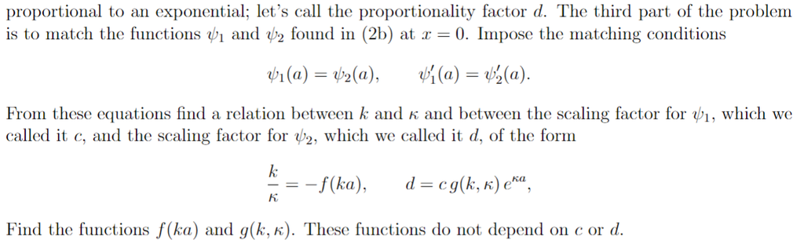

Lets do it. $$ \psi_1(a) = c\sin(k*a) \\ \psi_2(a) = de^{-\kappa a} \\ \psi_1'(a) = ck \cos(k*a) \\ \psi_2'(a) = -d\kappa e^{-\kappa *a} \\ \implies ck \cos(k*a) + d\kappa e^{-\kappa *a} = 0 \\ \implies c\sin(k*a) - de^{-\kappa a} = 0 \\ \kappa(c\sin(k*a) - de^{-\kappa a}) \\ $$ We can add the zeroes together $$ ck \cos(k*a) + d\kappa e^{-\kappa *a} + c\kappa\sin(k*a) - \kappa de^{-\kappa a} = 0 \\ ck \cos(k*a) = -c\kappa\sin(k*a)\\ \frac{k}{\kappa} = -\frac{\sin(ka)}{\cos(ka)}-f(ka) $$ g is simple $$ de^{-\kappa a}=c\sin(k*a) \\ d =\frac{c\sin(k*a)}{e^{-\kappa a}}= c \sin(k*a)e^{\kappa a} \\ g(k) = \sin(k*a) $$ Wait, is it simple? $$ \implies ck \cos(k*a) + d\kappa e^{-\kappa *a} = 0\\ d\kappa e^{-\kappa *a} = - ck \cos(k*a) \\ d = c(-\frac{k}{\kappa}\cos(k*a))e^{\kappa a}\\ g(k,\kappa) = -\frac{k}{\kappa}\cos(k*a) $$

I'm not quite sure if the first formula is correct, but I'll leave it in anyways since I know the second one is what we were going for.